# PCA

Amber Chang

2019/8/3

## **資料輸入與前處理**

```r
# Required Library
library("tidyverse")
setwd("C:/Users/TzuTzu/Desktop/ri/pca")
financial.data <- read_csv("2017_financial index_163 comp.csv")
#roe權益報酬率, roa資產報酬率
head(financial.data, 5)
```

```
## # A tibble: 5 x 17
##   comp_id   roe   roa profit_margin_r~ gross_margin_ra~ expense_rate
##     <dbl> <dbl> <dbl>            <dbl>            <dbl>        <dbl>
## 1    2303  3.06  2.21             4.4              18.1         14.8
## 2    2330 23.6  17.8             39.4              50.6         11.0
## 3    2337 25.7  14.3             16.8              37.0         20.1
## 4    2342 -3.41 -0.72             3.86             16.9         13
## 5    2344 10.9   7.69            14.0              34.3         20.3
## # ... with 11 more variables: asset_turnover <dbl>,
## #   inventory_turnover <dbl>, equity_turnnover <dbl>,
## #   rev_growth_rate <dbl>, margin_growth_rate <dbl>,
## #   op_profit_growth_rate <dbl>, cash_reinv_rate <dbl>,
## #   asset_growth_rate <dbl>, current_ratio <dbl>, quick_rartio <dbl>,
## #   debt_ratio <dbl>
```

## **資料探索**

由結果可知，roe之Max表示，此公司每募得一塊錢之股數，可賺0.37元。

profit_margin_rate - 每銷售一元，可得之獲利。profit_margin_rate之Min表示，每銷售1元，賠2元。

debt_ratio - 負債比。debt_ratio之Min表示，總資產之0.97%為負債買來的。

```r
summary(financial.data[, 2:ncol(financial.data)])
```

```
##       roe                 roa            profit_margin_rate
##  Min.   :-245.2000   Min.   :-132.5700   Min.   :-252.05
##  1st Qu.:  -0.2825   1st Qu.:  -0.2225   1st Qu.:  -0.50
##  Median :   7.9800   Median :   5.8200   Median :   7.72
##  Mean   :   4.3588   Mean   :   4.1785   Mean   :   3.46
##  3rd Qu.:  16.5400   3rd Qu.:  11.5100   3rd Qu.:  16.13
##  Max.   :  37.0100   Max.   :  28.9300   Max.   :  51.67
##  gross_margin_rate  expense_rate    asset_turnover  inventory_turnover
##  Min.   :-27.60    Min.   :  1.78   Min.   :0.030   Min.   : 0.000
##  1st Qu.: 18.39    1st Qu.: 10.78   1st Qu.:0.530   1st Qu.: 3.092
##  Median : 29.91    Median : 19.43   Median :0.720   Median : 4.370
##  Mean   : 31.19    Mean   : 27.96   Mean   :0.878   Mean   : 6.227
##  3rd Qu.: 41.48    3rd Qu.: 34.67   3rd Qu.:1.048   3rd Qu.: 6.475
##  Max.   :100.00    Max.   :255.18   Max.   :5.110   Max.   :56.810
##  equity_turnnover rev_growth_rate   margin_growth_rate
##  Min.   : 0.030   Min.   :-41.470   Min.   :-328.530
##  1st Qu.: 0.745   1st Qu.: -4.827   1st Qu.:  -9.572
##  Median : 1.035   Median :  5.745   Median :   8.200
##  Mean   : 1.447   Mean   : 12.815   Mean   :  24.434
##  3rd Qu.: 1.665   3rd Qu.: 17.852   3rd Qu.:  27.150
##  Max.   :10.080   Max.   :573.570   Max.   : 722.800
##  op_profit_growth_rate cash_reinv_rate   asset_growth_rate
##  Min.   :-449.33       Min.   :-62.240   Min.   :-52.860
##  1st Qu.: -15.50       1st Qu.: -3.237   1st Qu.: -3.560
##  Median :  15.76       Median :  2.620   Median :  4.240
##  Mean   :  36.69       Mean   :  1.731   Mean   :  7.537
##  3rd Qu.:  67.62       3rd Qu.:  8.582   3rd Qu.: 13.447
##  Max.   :1708.73       Max.   : 35.170   Max.   :161.800
##  current_ratio      quick_rartio       debt_ratio
##  Min.   :  50.35   Min.   :  19.12   Min.   : 0.97
##  1st Qu.: 187.37   1st Qu.: 130.28   1st Qu.:17.72
##  Median : 297.32   Median : 206.93   Median :26.68
##  Mean   : 394.05   Mean   : 300.61   Mean   :30.27
##  3rd Qu.: 454.46   3rd Qu.: 328.61   3rd Qu.:43.47
##  Max.   :3783.42   Max.   :3748.99   Max.   :94.24
```

### **相關係數**

**相關係數** - 了解變數間彼此之相關程度。

```r
cor(financial.data[, 2:ncol(financial.data)])
```

```
##                                 roe          roa profit_margin_rate
## roe                    1.000000e+00  0.927613723        0.769836624
## roa                    9.276137e-01  1.000000000        0.849678033
## profit_margin_rate     7.698366e-01  0.849678033        1.000000000
## gross_margin_rate      2.639333e-01  0.316508192        0.276079736
## expense_rate          -5.639643e-01 -0.602167492       -0.768924244
## asset_turnover         1.479487e-01  0.166463783        0.116560159
## inventory_turnover     6.099483e-02  0.049871996        0.096369338
## equity_turnnover      -8.465143e-02  0.038691090        0.030993761
## rev_growth_rate        1.788903e-01  0.182344013        0.112338020
## margin_growth_rate     4.237200e-02  0.025256508        0.008797824
## op_profit_growth_rate  1.632351e-01  0.146719332        0.138618099
## cash_reinv_rate        5.184223e-01  0.504324078        0.477952503
## asset_growth_rate      3.667274e-01  0.388442882        0.300383311
## current_ratio          4.332876e-05 -0.006202091       -0.077164016
## quick_rartio           5.196865e-02  0.046996374       -0.015659771
## debt_ratio            -1.258534e-01 -0.053587292        0.034495869
##                       gross_margin_rate expense_rate asset_turnover
## roe                          0.26393332  -0.56396427     0.14794874
## roa                          0.31650819  -0.60216749     0.16646378
## profit_margin_rate           0.27607974  -0.76892424     0.11656016
## gross_margin_rate            1.00000000   0.39128488    -0.27028252
## expense_rate                 0.39128488   1.00000000    -0.29526650
## asset_turnover              -0.27028252  -0.29526650     1.00000000
## inventory_turnover          -0.31354281  -0.26958440     0.29470755
## equity_turnnover            -0.33231257  -0.24999003     0.81529132
## rev_growth_rate             -0.04901623  -0.14229687     0.64183724
## margin_growth_rate          -0.03352279  -0.02418444     0.09165550
## op_profit_growth_rate        0.12722264  -0.04348225     0.10178782
## cash_reinv_rate              0.13386636  -0.36882576    -0.02304687
## asset_growth_rate            0.19833667  -0.15952707     0.24830284
## current_ratio                0.47049269   0.37547646    -0.20018000
## quick_rartio                 0.49806646   0.33611349    -0.23187752
## debt_ratio                  -0.43050696  -0.30251126     0.25122647
##                       inventory_turnover equity_turnnover rev_growth_rate
## roe                          0.060994826      -0.08465143     0.178890323
## roa                          0.049871996       0.03869109     0.182344013
## profit_margin_rate           0.096369338       0.03099376     0.112338020
## gross_margin_rate           -0.313542810      -0.33231257    -0.049016229
## expense_rate                -0.269584397      -0.24999003    -0.142296865
```

[output cut: 47 more lines]

```
## roa                    0.046996374 -5.358729e-02
## profit_margin_rate    -0.015659771  3.449587e-02
## gross_margin_rate      0.498066464 -4.305070e-01
## expense_rate           0.336113493 -3.025113e-01
## asset_turnover        -0.231877517  2.512265e-01
## inventory_turnover    -0.120757063  1.939272e-01
## equity_turnnover      -0.295895701  6.019729e-01
## rev_growth_rate        0.008888558 -6.813672e-03
## margin_growth_rate    -0.019162942 -5.363832e-02
## op_profit_growth_rate -0.009133092 -4.886632e-05
## cash_reinv_rate        0.037138507  1.151498e-02
## asset_growth_rate      0.066042364  1.037806e-01
## current_ratio          0.975353040 -5.861077e-01
## quick_rartio           1.000000000 -5.246527e-01
## debt_ratio            -0.524652674  1.000000e+00
```

**視覺化相關係數** - 喜歡使用**heatmap(熱圖)**視覺化變數相知相關程度。

- 如果要使用`ggplot2`繪製相關係數之熱圖，需先將資料整理成tidy(變數1-變數2-相關係數)之資料架構

→ **矩陣格式轉成tidy** - 利用`reshape2`套件中的`melt`函數。

```r
#value為相關係數
library(reshape2)
head(melt(cor(financial.data[, 2:ncol(financial.data)])), 5)
```

```
##                 Var1 Var2      value
## 1                roe  roe  1.0000000
## 2                roa  roe  0.9276137
## 3 profit_margin_rate  roe  0.7698366
## 4  gross_margin_rate  roe  0.2639333
## 5       expense_rate  roe -0.5639643
```

**相關係數熱圖**

由結果可知，

1.盈利能力變數彼此間高度相關。

2.營業費用率顯然與盈利能力負相關。

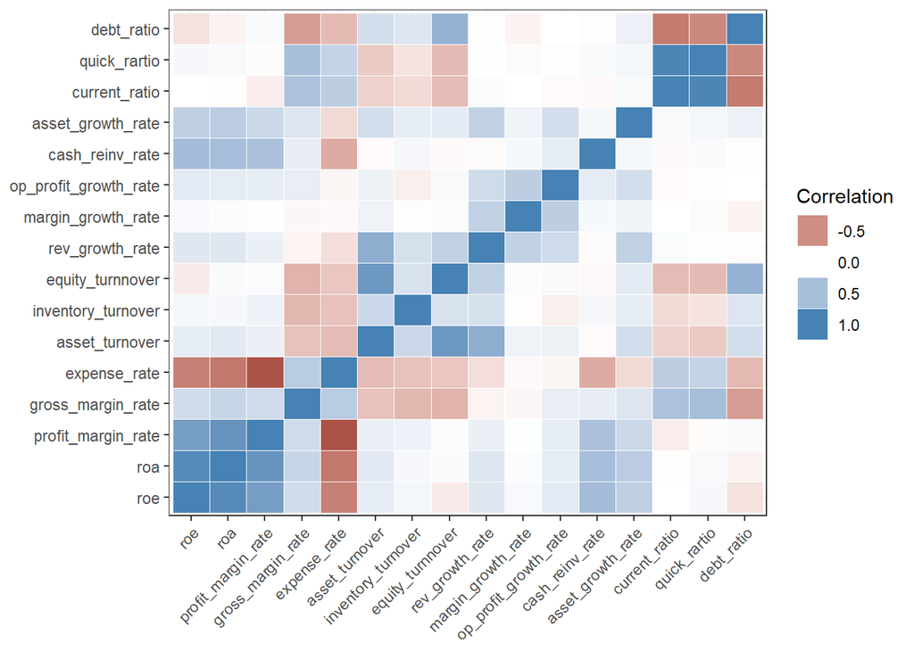

```r
ggplot(melt(cor(financial.data[, 2:ncol(financial.data)])),
       aes(Var1, Var2)) + #aes(橫軸, 縱軸)
  geom_tile(aes(fill = value), colour = "white") + #colour格子外框

#fill裡如何上色, scale_fill_gradient2漸層色
  scale_fill_gradient2(low = "firebrick4", high = "steelblue", #firebrick4深紅, steelblue深藍
                       mid = "white", midpoint = 0) + #midpoint中間點定義之值

#ggplot2索引
  guides(fill=guide_legend(title="Correlation")) + #guide_legend圖標
  theme_bw() +
  theme(axis.text.x = element_text(angle = 45, hjust = 1, vjust = 1),
        axis.title = element_blank())
```

## **資料探索**

### **主成分分析**

```r
pca.model <- prcomp(financial.data[, 2:ncol(financial.data)], scale = T) #scale = T,將資料先標準化

#sdev每PCA可解釋的變異數
#rotation係數矩陣
#center標準化後變數之中心
#scale 變數尺度
names(pca.model)
```

```
## [1] "sdev"     "rotation" "center"   "scale"    "x"
```

- 透過`summary`函數，查看主成份分析每個主成分之解釋變異程度

由結果可知，只要六個主成份就能解釋80%的資料變異P。

```r
summary(pca.model)
```

```
## Importance of components:
##                           PC1    PC2    PC3     PC4     PC5     PC6
## Standard deviation     2.0330 1.8739 1.4399 1.16215 1.01323 0.91896
## Proportion of Variance 0.2583 0.2195 0.1296 0.08441 0.06417 0.05278
## Cumulative Proportion  0.2583 0.4778 0.6074 0.69177 0.75594 0.80872
##                            PC7     PC8     PC9    PC10    PC11    PC12
## Standard deviation     0.87186 0.77645 0.73927 0.67853 0.56103 0.50353
## Proportion of Variance 0.04751 0.03768 0.03416 0.02878 0.01967 0.01585
## Cumulative Proportion  0.85623 0.89391 0.92806 0.95684 0.97651 0.99236
##                           PC13    PC14    PC15    PC16
## Standard deviation     0.27912 0.15178 0.12692 0.07223
## Proportion of Variance 0.00487 0.00144 0.00101 0.00033
## Cumulative Proportion  0.99723 0.99867 0.99967 1.00000
```

- 可透過解釋變異/累積解釋比率圖，選取主成份
- var -主成份解釋多少變異數
- prop - 主成份解釋變異數比率=PC變異數/總變異
- cum_prop - 該主成份解釋多少變異數之累積比率

由於`pac.model`只能抓出每個PC的標準差`pca.model$sdev`。

→ 需建立以下表格，計算上述各值。

```r
var.exp <- tibble(
  pc = paste0("PC_", formatC(1:16, width=2, flag="0")), #pc主成份
  var = pca.model$sdev^2, #var便異數
  prop = (pca.model$sdev)^2 / sum((pca.model$sdev)^2), #prop該主成份之解釋變異數
  cum_prop = cumsum((pca.model$sdev)^2 / sum((pca.model$sdev)^2))) #cum_prop累積比率

head(var.exp, 5)
```

```
## # A tibble: 5 x 4
##   pc      var   prop cum_prop
##   <chr> <dbl>  <dbl>    <dbl>
## 1 PC_01  4.13 0.258     0.258
## 2 PC_02  3.51 0.219     0.478
## 3 PC_03  2.07 0.130     0.607
## 4 PC_04  1.35 0.0844    0.692
## 5 PC_05  1.03 0.0642    0.756
```

```r
library(plotly)
```

### **解釋變異條狀圖**

由結果可知，取前六個主成份即可。

```r
plot_ly(
  x = var.exp$pc,
  y = var.exp$var,
  type = "bar"
) %>%
  layout(
    title = "Variance Explained by Each Principal Component",
    xaxis = list(type = 'Principal Component', tickangle = -60),
    yaxis = list(title = 'Variance'),
    margin = list(r = 30, t = 50, b = 70, l = 50)
  )
```

[interactive chart not shown]

```r
plot_ly(
  x = var.exp$pc,
  y = var.exp$cum_prop,
  type = "bar"
) %>%
  layout(
    title = "Cumulative Proportion by Each Principal Component",
    xaxis = list(type = 'Principal Component', tickangle = -60),
    yaxis = list(title = 'Proportion'),
    margin = list(r = 30, t = 50, b = 70, l = 50)
  )
```

[interactive chart not shown]

### **主成份係數矩陣**

**主成份係數矩陣** - 更仔細了解每個主成份之係數，以便解釋主成份內容

```r
head(pca.model$rotation, 5)
```

```
##                            PC1         PC2         PC3         PC4
## roe                 0.35051324 -0.30782632  0.09992653 -0.01265022
## roa                 0.37209821 -0.29926633  0.09449066 -0.04995561
## profit_margin_rate  0.37420084 -0.25303809  0.17092884 -0.03880183
## gross_margin_rate  -0.07651638 -0.40212860 -0.08460058  0.03060840
## expense_rate       -0.40631496 -0.01939565 -0.21713947  0.05973301
##                            PC5         PC6         PC7         PC8
## roe                -0.01349820  0.03456689 -0.15906558  0.07416622
## roa                 0.08224210 -0.01771183 -0.12638004 -0.00498288
## profit_margin_rate  0.02278657 -0.01866967 -0.06950275 -0.16719939
## gross_margin_rate   0.40812461  0.01386915  0.01697671  0.32211008
## expense_rate        0.23611021  0.04571298  0.09960746  0.38295533
##                             PC9        PC10       PC11       PC12
## roe                -0.009130585  0.09361023 -0.2382325  0.5499299
## roa                -0.056233502 -0.08161125 -0.1409867  0.3340492
## profit_margin_rate  0.052479810 -0.34314001  0.2211807 -0.3876528
## gross_margin_rate  -0.272326633 -0.47017407  0.1271494 -0.1790633
## expense_rate       -0.239559563 -0.01790162 -0.1261054  0.2792875
##                           PC13         PC14        PC15        PC16
## roe                -0.37672698 -0.457679257 -0.13920077 -0.03555639
## roa                 0.58984636  0.480985247  0.11922953  0.05209979
## profit_margin_rate -0.12171515  0.004062131 -0.05631017 -0.62759258
## gross_margin_rate  -0.13036971 -0.066220940 -0.01451809  0.43415917
## expense_rate        0.04837154  0.096936721 -0.02701126 -0.63664808
```

**主成份係數矩陣熱圖**

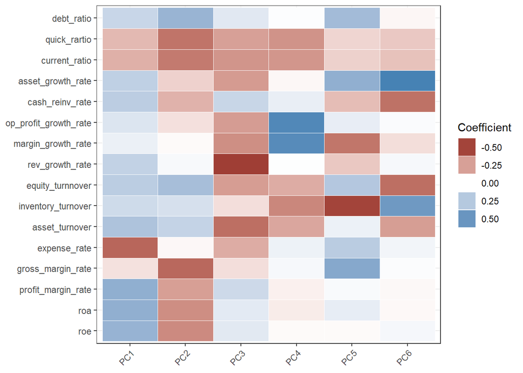

```r
ggplot(melt(pca.model$rotation[, 1:6]), aes(Var2, Var1)) +
  geom_tile(aes(fill = value), colour = "white") +
  scale_fill_gradient2(low = "firebrick4", high = "steelblue",
                       mid = "white", midpoint = 0) +
  guides(fill=guide_legend(title="Coefficient")) +
  theme_bw() +
  theme(axis.text.x = element_text(angle = 45, hjust = 1, vjust = 1),
        axis.title = element_blank())
```

### **非負稀疏主成分分析**

**非負稀疏主成分分析** - 由於原先的主成份很解釋，改採用非負稀疏主成份分析

→ 利用`nsprcomp`套件中之`nscumcomp`

- k:非0係數個數，通常是「每個主成份期待非0係數個數(=希望每個PCA有幾個變數)」*變數個數
- nneg:是否希望所有係數都是負的，nneg = T即有非負限制

```r
set.seed(1234)
#install.packages("nsprcomp")
library(nsprcomp)

#k可選80~100之間
nspca.model <- nscumcomp(
  financial.data[, 2:17],
  k = 90, nneg = T,
  scale. = T)
```

```r
var.exp <- tibble(
  pc = paste0("PC_", formatC(1:16, width=2, flag="0")),
  var = nspca.model$sdev^2,
  prop = (nspca.model$sdev)^2 / sum((nspca.model$sdev)^2),
  cum_prop = cumsum((nspca.model$sdev)^2 / sum((nspca.model$sdev)^2)))

head(var.exp, 5)
```

```
## # A tibble: 5 x 4
##   pc      var   prop cum_prop
##   <chr> <dbl>  <dbl>    <dbl>
## 1 PC_01 1.44  0.158     0.158
## 2 PC_02 1.19  0.132     0.290
## 3 PC_03 1.07  0.118     0.408
## 4 PC_04 0.906 0.0999    0.508
## 5 PC_05 0.888 0.0979    0.606
```

- 可透過解釋變異與累積比率決定主成份個數

由圖可知，可採用8個主成份。

```r
library(plotly)

plot_ly(
  x = var.exp$pc,
  y = var.exp$var,
  type = "bar"
) %>%
  layout(
    title = "Variance Explained by Each Principal Component",
    xaxis = list(type = 'Principal Component', tickangle = -60),
    yaxis = list(title = 'Variance'),
    margin = list(r = 30, t = 50, b = 70, l = 50)
  )
```

[interactive chart not shown]

```r
plot_ly(
  x = var.exp$pc,
  y = var.exp$cum_prop,
  type = "bar"
) %>%
  layout(
    title = "Cumulative Proportion by Each Principal Component",
    xaxis = list(type = 'Principal Component', tickangle = -60),
    yaxis = list(title = 'Proportion'),
    margin = list(r = 30, t = 50, b = 70, l = 50)
  )
```

[interactive chart not shown]

**非負稀疏主成份之係數權重熱圖**

- 主成份1重點為「股東權益獲利與成長能力」
- 主成份2重點為「資產獲利能力」
- 主成份3重點為「毛利與週轉率」

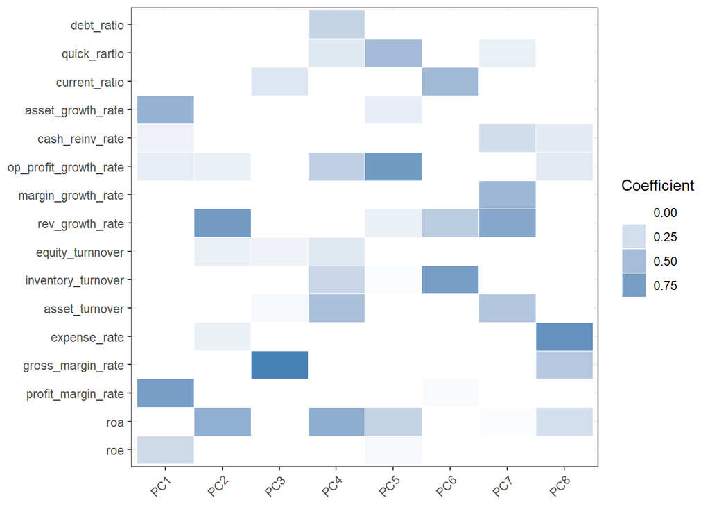

```r
ggplot(melt(nspca.model$rotation[, 1:8]), aes(Var2, Var1)) +
  geom_tile(aes(fill = value), colour = "white") +
  scale_fill_gradient2(low = "white", high = "steelblue") +
  guides(fill=guide_legend(title="Coefficient")) +
  theme_bw() +
  theme(axis.text.x = element_text(angle = 45, hjust = 1, vjust = 1),
        axis.title = element_blank())
```

## **公司個別分析**

- 繪製「主成份分數」與「該主成份係數最大變數」之散佈圖，可找出幾種特別怪異之公司：

看法 → 給定ROE，PC1特別卓越為6684安格 給定PC1，ROE超級低為6291沛亨

**主成份分數與該主成份係數最大變數之散佈圖**

```r
nspca.score <- data.frame(nspca.model$x) #nspca.model$x抓出PCA的分數

#命名row
row.names(nspca.score) <- financial.data$comp_id

plot_ly(
  x = nspca.score[, 1],
  y = financial.data$roe,
  text = financial.data$comp_id,
  type = "scatter",
  mode = "markers"
) %>% layout(
    title = "ROE v.s. PC 1 Score: Scatter Plot",
    xaxis = list(title = 'Principal Component 1'),
    yaxis = list(title = 'Return on Equity'),
    margin = list(r = 30, t = 50, b = 70, l = 50)
  )
```

[interactive chart not shown]

- 透過不同主成份散佈圖，也可找到很多面向都傑出之公司

由圖可知，3529力旺, 6643丹星, 6684安格在「資產獲利能力」與「毛利率週轉率」特別傑出，值得關注。

```r
plot_ly(
  x = nspca.score[, 2],
  y = nspca.score[, 3],
  text = financial.data$comp_id,
  type = "scatter",
  mode = "markers"
) %>% layout(
    title = "PC 2 v.s. PC 3 Score: Scatter Plot",
    xaxis = list(title = 'Principal Component 2'),
    yaxis = list(title = 'Principal Component 3'),
    margin = list(r = 30, t = 50, b = 70, l = 50)
  )
```

[interactive chart not shown]